# Final key

# Instructions

- **Be sure to read every question carefully and answer all parts.**
- **Clarification questions should be sent to the professors or TAs.** We will post to Piazza if everyone should see the answer. No consultation with other students or outside experts is allowed during the exam period (including R programming). You may use any notes / printed material / online resources.
- **Include all `R` code used to answer each question.** Be sure to include a command so that your results are printed out to the knitted output. Be sure to run all code again before submitting (Run -> Run All) so that all answers are included in your output.
- Some questions can be answered without any `R` code.
- **Use http://www.tablesgenerator.com/markdown_tables to easily convert excel tables to markdown** You can create your model tables in Excel, paste them into the website, and then copy the correctly formatted table back into this document.
- **Do not include your name in the file name.** We hide your names during grading to prevent bias.

[output not shown]

# Question 2

A researcher ran a microcosm experiment to study the effect of nitrogen runoff on biodiversity in wetland communities. They were interested in how weeds might out-compete native grasses under elevated nitrogen levels. They chose three weed species to test. The experiment was run in small artificial wetlands (rectangular wire baskets) that included a combination of a native grass and single weed species.

The artificial wetlands were set in large trays with water containing a defined level of nitrogen. In total, there were 8 trays, with two trays for each of the four levels of nitrogen. Each tray held three artificial wetlands, one for each of the three weed species.

At the end of 8 weeks, the plant material in each wetland was harvested and divided between weed and native grass, and the percentage of biomass that remained as grass was recorded.

```r
biomass_1 = read.csv('weed_biomass_small.csv',stringsAsFactors = TRUE)
str(biomass_1)
```

```
'data.frame':   24 obs. of  5 variables:
 $ tray        : Factor w/ 8 levels "Tray_1","Tray_2",..: 1 1 1 2 2 2 3 3 3 4 ...
 $ wetland     : Factor w/ 24 levels "Wetland_1","Wetland_10",..: 1 12 18 19 20 21 22 23 24 2 ...
 $ nitrogen    : Factor w/ 4 levels "Nitr_1","Nitr_2",..: 1 1 1 2 2 2 3 3 3 4 ...
 $ weed        : Factor w/ 3 levels "Weed_1","Weed_2",..: 1 2 3 1 2 3 1 2 3 1 ...
 $ perc_biomass: num  87.2 70.4 75.9 80.5 59.2 59.5 76.8 47.8 48.4 77.7 ...
```

## 2.1 Create a design table for this experiment [8 points]

Give a justification for each EU that you specify.

| Structure | Variable | Type | # levels | EU |
| --- | --- | --- | --- | --- |
| Treatment | nitrogen | Categ | 4 | tray |
|  | weed | Categ | 3 | tray:weed |
|  | nitrogen:weed | Categ | 12 | tray:weed |
| Design | tray | Categ | 8 |  |
|  | tray:weed | Categ | 24 |  |
|  | wetland | Categ | 24 |  |
| Response | perc_biomass | Numeric | 24 |  |

> tray is a block for weed and nitrogen weed, which determines their EUs. Nitrogen levels are randomized to trays, thus their EU. Note: since tray is nested in nitrogen, we don’t need to make tray:nitrogen, or tray:nitrogen:weed. This means that tray:weed is a fine EU for nitrogen:weed. tray:nitrogen:weed would also be acceptable. wetland is also not required for the table. Accept tray:nitrogen

> 5 for terms, 3 for EU

## 2.2 Write an appropriate linear model for the analysis [4 points]

```r
biomass_model_1 <- lmer(perc_biomass ~ nitrogen + weed + nitrogen:weed + (1|tray),data = biomass_1)
```

> -1 per inconsistency with table

## 2.3 How much evidence do you have that nitrogen levels EVER affect the proportion of non-weed biomass? [6 points]

Use an ANOVA to answer this question. Provide a statement describing the interpretation of the ANOVA results. Be very specific about how you measured the evidence and what you can conclude from this analysis.

```r
reduced_biomass_model_1 = lmer(perc_biomass ~ weed + nitrogen:weed + (1|tray),data = biomass_1)
anova(reduced_biomass_model_1,ddf = 'K')
```

```
Type III Analysis of Variance Table with Kenward-Roger's method
              Sum Sq Mean Sq NumDF  DenDF F value
weed          252.02 126.012     2 8.0000  48.779
weed:nitrogen 576.11  64.013     9 6.9159  23.240
                 Pr(>F)
weed          3.299e-05 ***
weed:nitrogen 0.0002253 ***
---
Signif. codes:
0 ‘***’ 0.001 ‘**’ 0.01 ‘*’ 0.05 ‘.’ 0.1 ‘ ’ 1
```

> There is strong evidence (p = 0.0002253) that nitrogen levels alter the perc_biomass at least for some weed species.

> 3 for model, 3 for interpretation

## 2.4 Estimate the effects of changing nitrogen levels on the percent of non-weed biomass [6 points]

Present a table/display giving estimates and confidence intervals for the nitrogen effects. Use 95% confidence intervals adjusted for the number of comparisons. Describe the findings. You do not need to specifically describe each contrast, but provide an overall summary of the main findings. You may include a figure if you’d like.

```r
nitrogen_means_1 = emmeans(biomass_model_1,specs = 'nitrogen',by = 'weed')
nitrogen_effects = contrast(nitrogen_means_1,method = 'pairwise')
summary(nitrogen_effects,level = 1-0.05/3,infer = T)
```

```
weed = Weed_1:
 contrast        estimate   SE  df lower.CL
 Nitr_1 - Nitr_2     2.55 3.55 5.3   -14.30
 Nitr_1 - Nitr_3     3.10 3.55 5.3   -13.75
 Nitr_1 - Nitr_4     6.10 3.55 5.3   -10.75
 Nitr_2 - Nitr_3     0.55 3.55 5.3   -16.30
 Nitr_2 - Nitr_4     3.55 3.55 5.3   -13.30
 Nitr_3 - Nitr_4     3.00 3.55 5.3   -13.85
 upper.CL t.ratio p.value
     19.4 0.718   0.8864
     19.9 0.872   0.8192
     22.9 1.717   0.4004
     17.4 0.155   0.9985
     20.4 0.999   0.7568
     19.8 0.844   0.8323

weed = Weed_2:
 contrast        estimate   SE  df lower.CL
 Nitr_1 - Nitr_2     9.35 3.55 5.3    -7.50
 Nitr_1 - Nitr_3    18.60 3.55 5.3     1.75
 Nitr_1 - Nitr_4    30.40 3.55 5.3    13.55
 Nitr_2 - Nitr_3     9.25 3.55 5.3    -7.60
 Nitr_2 - Nitr_4    21.05 3.55 5.3     4.20
 Nitr_3 - Nitr_4    11.80 3.55 5.3    -5.05
 upper.CL t.ratio p.value
     26.2 2.631   0.1455
     35.4 5.234   0.0108
     47.2 8.555   0.0011
     26.1 2.603   0.1502
     37.9 5.924   0.0062
     28.6 3.321   0.0680

weed = Weed_3:
 contrast        estimate   SE  df lower.CL
 Nitr_1 - Nitr_2    11.60 3.55 5.3    -5.25
 Nitr_1 - Nitr_3    20.60 3.55 5.3     3.75
 Nitr_1 - Nitr_4    30.50 3.55 5.3    13.65
 Nitr_2 - Nitr_3     9.00 3.55 5.3    -7.85
 Nitr_2 - Nitr_4    18.90 3.55 5.3     2.05
 Nitr_3 - Nitr_4     9.90 3.55 5.3    -6.95
 upper.CL t.ratio p.value
     28.4 3.264   0.0722
     37.4 5.797   0.0068
     47.3 8.583   0.0010
     25.8 2.533   0.1626
     35.7 5.318   0.0101
     26.7 2.786   0.1223

Degrees-of-freedom method: kenward-roger
Confidence level used: 0.983333333333333
Conf-level adjustment: tukey method for comparing a family of 4 estimates
P value adjustment: tukey method for comparing a family of 4 estimates
```

```r
cld(nitrogen_means_1,alpha = 0.05/3)
```

```
weed = Weed_1:
 nitrogen emmean   SE  df lower.CL upper.CL .group
 Nitr_4     76.6 2.51 5.3     70.2     83.0  1
 Nitr_3     79.6 2.51 5.3     73.2     86.0  1
 Nitr_2     80.2 2.51 5.3     73.8     86.5  1
 Nitr_1     82.7 2.51 5.3     76.3     89.1  1

weed = Weed_2:
 nitrogen emmean   SE  df lower.CL upper.CL .group
 Nitr_4     37.4 2.51 5.3     31.0     43.7  1
 Nitr_3     49.1 2.51 5.3     42.8     55.5  12
 Nitr_2     58.4 2.51 5.3     52.0     64.8   23
 Nitr_1     67.8 2.51 5.3     61.4     74.1    3

weed = Weed_3:
 nitrogen emmean   SE  df lower.CL upper.CL .group
 Nitr_4     40.1 2.51 5.3     33.7     46.5  1
 Nitr_3     50.0 2.51 5.3     43.6     56.4  12
 Nitr_2     59.0 2.51 5.3     52.6     65.4   23
 Nitr_1     70.6 2.51 5.3     64.2     77.0    3

Degrees-of-freedom method: kenward-roger
Confidence level used: 0.95
P value adjustment: tukey method for comparing a family of 4 estimates
significance level used: alpha = 0.0166666666666667
```

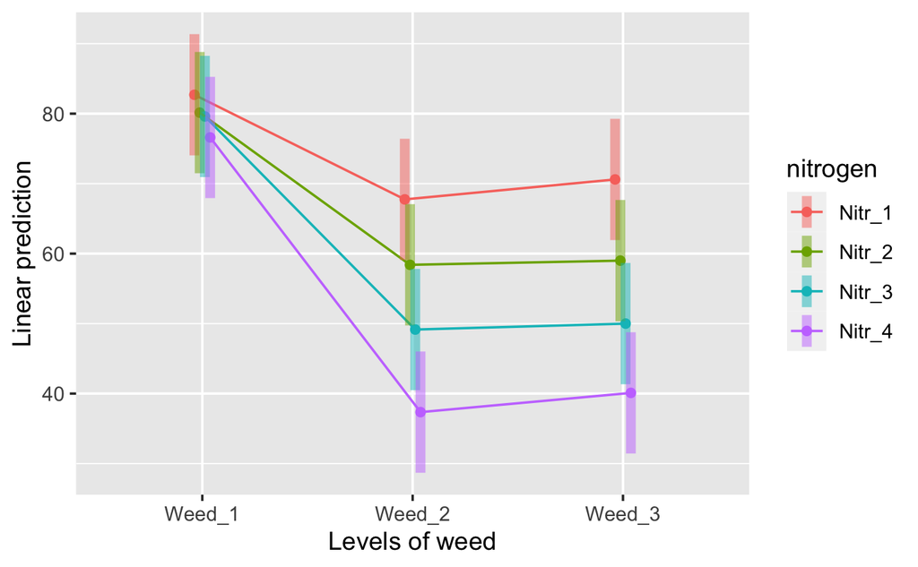

```r
emmip(nitrogen_means_1,nitrogen~weed,CIs = T,level = 1-0.05/3)
```

> The main findings are that increasing amounts of nitrogen decrease the percentage of grass biomass, but the effect is much stronger for weed species 2 and 3 than for weed 1. At alpha = 0.05, we cannot declare any effect of nitrogen for weed_1, but we can for the other two species.

> This can be answered with a CLD display, a table of the pairwise contrasts, or a table of contrasts against Nitr_1. They are not all needed. The figure is not required, but may help summarize conclusions. Check in summary(), cld(), and any figure that the alpha is corrected for the number of weed species.

> 3 for table, 3 for interpretation

## 2.5 You should have observed above that effects of nitrogen appear much greater for some weed species than others. [6 points]

Test this hypothesis using an ANOVA. Then estimate how much the nitrogen effects change for species “Weed_2” relative to species “Weed_1”. Describe the findings. Include a description of an example interaction effect.

```r
anova(biomass_model_1,ddf = 'K')
```

```
Type III Analysis of Variance Table with Kenward-Roger's method
              Sum Sq Mean Sq NumDF DenDF F value
nitrogen       127.5   42.49     3     4  16.447
weed          3540.2 1770.09     2     8 685.196
nitrogen:weed  448.6   74.77     6     8  28.945
                 Pr(>F)
nitrogen        0.01028 *
weed          1.135e-09 ***
nitrogen:weed 5.250e-05 ***
---
Signif. codes:
0 ‘***’ 0.001 ‘**’ 0.01 ‘*’ 0.05 ‘.’ 0.1 ‘ ’ 1
```

```r
biomass_effects_by_contrast = emmeans(nitrogen_effects,specs = 'weed',by = 'contrast')
contrast(biomass_effects_by_contrast,'trt.vs.ctrl')
```

```
contrast = Nitr_1 - Nitr_2:
 contrast1       estimate   SE df t.ratio p.value
 Weed_2 - Weed_1     6.80 2.27  8  2.992  0.0322
 Weed_3 - Weed_1     9.05 2.27  8  3.981  0.0077

contrast = Nitr_1 - Nitr_3:
 contrast1       estimate   SE df t.ratio p.value
 Weed_2 - Weed_1    15.50 2.27  8  6.819  0.0003
 Weed_3 - Weed_1    17.50 2.27  8  7.699  0.0001

contrast = Nitr_1 - Nitr_4:
 contrast1       estimate   SE df t.ratio p.value
 Weed_2 - Weed_1    24.30 2.27  8 10.691  <.0001
 Weed_3 - Weed_1    24.40 2.27  8 10.735  <.0001

contrast = Nitr_2 - Nitr_3:
 contrast1       estimate   SE df t.ratio p.value
 Weed_2 - Weed_1     8.70 2.27  8  3.827  0.0095
 Weed_3 - Weed_1     8.45 2.27  8  3.718  0.0111

contrast = Nitr_2 - Nitr_4:
 contrast1       estimate   SE df t.ratio p.value
 Weed_2 - Weed_1    17.50 2.27  8  7.699  0.0001
 Weed_3 - Weed_1    15.35 2.27  8  6.753  0.0003

contrast = Nitr_3 - Nitr_4:
 contrast1       estimate   SE df t.ratio p.value
 Weed_2 - Weed_1     8.80 2.27  8  3.871  0.0089
 Weed_3 - Weed_1     6.90 2.27  8  3.036  0.0302

Degrees-of-freedom method: kenward-roger
P value adjustment: dunnettx method for 2 tests
```

> There is strong evidence (p = 5.250e-05) that the effects of nitrogen change depending on species. Overall, effects of nitrogen are always greater for “Weed_2” than “Weed_1”, ranging from ~6-24 precentages larger depending on which nitrogen levels are compared. For example, the Nitr_1 - Nitr_4 effect caused a change in perc_biomass by 24.3 more in Weed_2 than Weed_1.

> 2 for ANOVA, 2 for specific effects, 2 for example interpretation

## 2.6 Which specific effects would you expect to be estimated with the greatest precision? Why? [5 points]

The previous questions used nitrogen as the focal treatment and calculated specific effects of nitrogen for each weed species. We could have instead treated weed species as the focal treatment and calculated specific effects for each level of nitrogen. Would each specific effect in each set have the same standard error and size of its confidence interval? Why or why not?

> We would expect the specific effects of weed species to be estimated with greater precision because these comparisons happen within trays, while the nitrogen specific effects are estimated across trays. This means that the variation among trays contributes to the error in estimating nitrogen effects but not weed species effects. We don’t expect the various specific effects of Nitrogen do have different SEs. All SEs for nitrogen will be the same.

```r
weed_means_1 = emmeans(biomass_model_1,specs = 'weed',by = 'nitrogen')
weed_effects = contrast(weed_means_1,method = 'pairwise')
summary(weed_effects,level= 1-0.05/4,infer = T)
```

```
nitrogen = Nitr_1:
 contrast        estimate   SE df lower.CL upper.CL t.ratio p.value
 Weed_1 - Weed_2    14.95 1.61  8     8.81    21.09  9.301  <.0001
 Weed_1 - Weed_3    12.10 1.61  8     5.96    18.24  7.528  0.0002
 Weed_2 - Weed_3    -2.85 1.61  8    -8.99     3.29 -1.773  0.2385

nitrogen = Nitr_2:
 contrast        estimate   SE df lower.CL upper.CL t.ratio p.value
 Weed_1 - Weed_2    21.75 1.61  8    15.61    27.89 13.532  <.0001
 Weed_1 - Weed_3    21.15 1.61  8    15.01    27.29 13.159  <.0001
 Weed_2 - Weed_3    -0.60 1.61  8    -6.74     5.54 -0.373  0.9267

nitrogen = Nitr_3:
 contrast        estimate   SE df lower.CL upper.CL t.ratio p.value
 Weed_1 - Weed_2    30.45 1.61  8    24.31    36.59 18.945  <.0001
 Weed_1 - Weed_3    29.60 1.61  8    23.46    35.74 18.416  <.0001
 Weed_2 - Weed_3    -0.85 1.61  8    -6.99     5.29 -0.529  0.8597

nitrogen = Nitr_4:
 contrast        estimate   SE df lower.CL upper.CL t.ratio p.value
 Weed_1 - Weed_2    39.25 1.61  8    33.11    45.39 24.420  <.0001
 Weed_1 - Weed_3    36.50 1.61  8    30.36    42.64 22.709  <.0001
 Weed_2 - Weed_3    -2.75 1.61  8    -8.89     3.39 -1.711  0.2593

Degrees-of-freedom method: kenward-roger
Confidence level used: 0.9875
Conf-level adjustment: tukey method for comparing a family of 3 estimates
P value adjustment: tukey method for comparing a family of 3 estimates
```

> -1 if only answer 1st question

# Challenge problem: (5 bonus points but only if 100% correct. Max score = 70)

The above data set is from a classic experiment used to demonstrate split plots. In the original experiment, each of the 24 wetlands was further divided into two halves, and one half was randomly selected for trimming (clipping) to simulate mowing after 1 week. Furthermore, the 8 trays were divided between two tables, with one tray/nitrogen level on each table. Create the design table for this experiment and write the corresponding linear model

```r
biomass_full = read.csv('weed_biomass2.csv',stringsAsFactors = TRUE)
str(biomass_full)
```

```
'data.frame':   48 obs. of  7 variables:
 $ table       : Factor w/ 2 levels "Table1","Table2": 1 1 1 1 1 1 1 1 1 1 ...
 $ tray        : Factor w/ 8 levels "Tray_1","Tray_2",..: 1 1 1 1 1 1 2 2 2 2 ...
 $ wetland     : Factor w/ 24 levels "Wetland_1","Wetland_10",..: 1 1 12 12 18 18 19 19 20 20 ...
 $ nitrogen    : Factor w/ 4 levels "Nitr_1","Nitr_2",..: 1 1 1 1 1 1 2 2 2 2 ...
 $ clipping    : Factor w/ 2 levels "cut","none": 2 1 2 1 2 1 2 1 2 1 ...
 $ weed        : Factor w/ 3 levels "Weed_1","Weed_2",..: 1 1 2 2 3 3 1 1 2 2 ...
 $ perc_biomass: num  87.2 88.8 70.4 75.7 75.9 80.6 80.5 83.8 59.2 61.5 ...
```

| Structure | Variable | Type | # levels | EU |
| --- | --- | --- | --- | --- |
| Treatment | nitrogen | Categ | 4 | table:nitrogen |
|  | weed | Categ | 3 | table:weed |
|  | clipping | Categ | 2 | table:clipping |
|  | nitrogen:weed | Categ | 12 | table:nitrogen:weed |
|  | nitrogen:clipping | Categ | 8 | table:nitrogen:clipping |
|  | weed:clipping | Categ | 6 | table:weed:clipping |
|  | nitrogen:weed:clipping | Categ | 24 | table:nitrogen:weed:clipping |
| Design | table | Categ | 2 |  |
|  | table:nitrogen | Categ | 8 |  |
|  | table:weed | Categ | 6 |  |
|  | table:clipping | Categ | 4 |  |
|  | table:nitrogen:weed | Categ | 24 |  |
|  | table:nitrogen:clipping | Categ | 16 |  |
|  | table:weed:clipping | Categ | 12 |  |
|  | table:nitrogen:weed:clipping | Categ | 48 |  |
|  | tray | Categ | 8 |  |
|  | wetland | Categ | 24 |  |
| Response | perc_biomass | Numeric | 48 |  |

```r
full_model = lmer(perc_biomass ~ table +
                    nitrogen+weed+clipping + nitrogen:weed + nitrogen:clipping + weed:clipping + nitrogen:weed:clipping +
                    (1|table:nitrogen) + (1|table:weed) + (1|table:clipping) +
                    (1|table:nitrogen:weed) + (1|table:nitrogen:clipping) + (1|table:weed:clipping),data = biomass_full)
```

```
boundary (singular) fit: see ?isSingular
Model failed to converge with 1 negative eigenvalue: -6.6e-01
```